# How to minimise wait time at supermarket self-checkout?

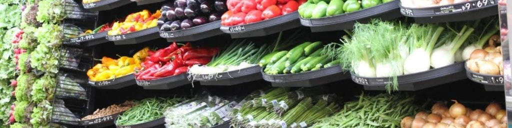

Image of vegetables.

This report is an exploration based on the data collected using the Supermarket Self-Checkout Google Form created as part of Project 2 and this project. The data collected is the observational data on self-checkout in different supermarkets, to see when and where is the best time and place to do your supermarket shopping in order to minimise the wait time to use the supermarket self-checkout kiosk.

## Best supermarket for self-checkout?

[figure not shown]

Image of supermarket logos.

Does the self-checkout time depend on the supermarket you are shopping at? If so, what supermarket should you go to in order to experience the shortest wait time?

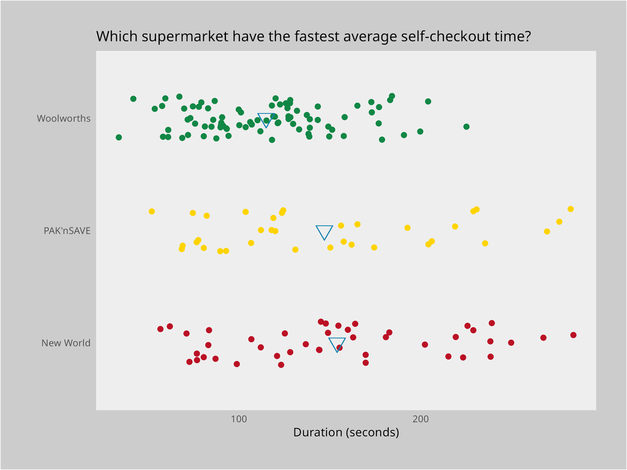

Scatter plot showing the average self-checkout time by Supermarkets.

It seems the average self-checkout time does slightly depend on the supermarket you go to, with Woolworths having a faster average self-checkout time, however, this is not by much. Therefore, the specific supermarket is not a major factor.

## Should you wait behind people who brought their own reusable bag?

[figure not shown]

Image of Woolworths/Countdown reusable bag.

Do people who bring their own bags to use finish their self-checkout faster than those who don’t? Perhaps people who didn’t bring their bags have a large purchase and will push the cart to their car, therefore, having a longer self-checkout duration.

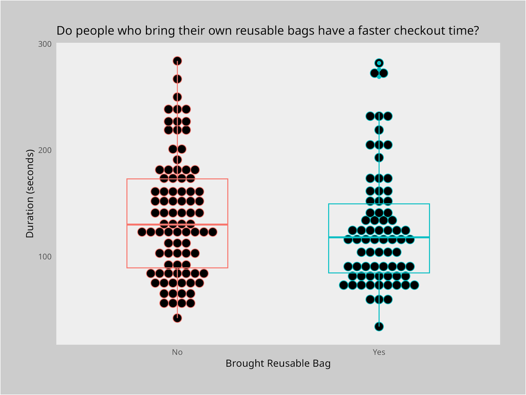

Dot plot and Box plot showing duration by using reusable bags.

There does not seem to be a difference between people who brought their reusable bags and those who didn’t. Therefore, if you wish to minimise the wait time at supermarket self-checkout, it does not matter if you wait behind people who brought their own bags or not.

## When is the best time to do your shopping?

Does the time you do your shopping matter?

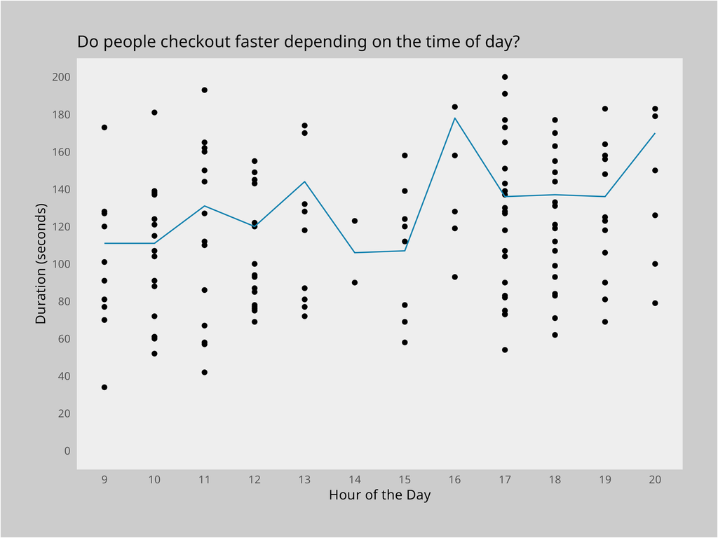

Point and line graph showing the self-checkout duration by time of day.

Looking at the graph, it seems that the self-checkout duration measured during 9am to 3pm seems to faster than those measured during 4pm to 8pm. This makes sense as most people would be busy at work or school during 9am to 3pm and therefore those shopping during those times tends to be buying smaller items for lunch. People shopping near 4pm to 8pm seems to be buying more items possibly for dinner and therefore take longer due to having more items to checkout.

## So how to minimise wait time at supermarket self-checkout?

Overall, it seems the particular supermarkets or whether the person brought their own reusable bag is not a big factor in determining the self-checkout duration. However, it seems if you wish to minimise the wait time, it’s best to shop during 9am to 3pm.